# Emeklilik Data

```r
library(readxl)
library(ggplot2)
library(dplyr)
library(tidyverse)
```

## Loading Data

Loading data with read_xlsx.

```r
#setwd("C:\\Users\\STUDENT\\Desktop\\R")
data <- read_xlsx("egmdata.xlsx",1)
```

First ten row of Data.

```r
data %>%
  tbl_df
```

```
## # A tibble: 1,368 x 15
##    date  pension_fund_co~ n_of_participan~ fund_size_parti~
##    <chr> <chr>                       <dbl>            <dbl>
##  1 06.0~ Aegon Emeklilik~            42826        139193651
##  2 06.0~ Allianz Hayat v~           118867       1840701596
##  3 06.0~ Allianz Yaşam v~           726684       7387398235
##  4 06.0~ Anadolu Hayat E~          1119572       9975066501
##  5 06.0~ Asya Emeklilik ~           129389        337754079
##  6 06.0~ Avivasa Emeklil~           876894      10550032358
##  7 06.0~ Axa Hayat ve Em~            33327        210804109
##  8 06.0~ BNP Paribas Car~           187289       1545869615
##  9 06.0~ Cigna Finans Em~           122997        564291355
## 10 06.0~ Fiba Emeklilik ~            38754        247746061
## # ... with 1,358 more rows, and 11 more variables: gov_contribution <dbl>,
## #   contribution <dbl>, n_of_pensioners <chr>, n_of_ind_contracts <dbl>,
## #   n_of_group_ind_contracts <chr>,
## #   n_of_employer_group_certificates <chr>, n_total <dbl>,
## #   size_of_ind_contracts <dbl>, size_of_group_ind_contracts <dbl>,
## #   size_of_employer_group_certificates <dbl>, size_total <dbl>
```

# Plots of ggplot2

We could see the relations with ggplot2 graphics. x coordinate is number of participants of employers and y coordinate is fund size of participants and color is contribution level of employers.

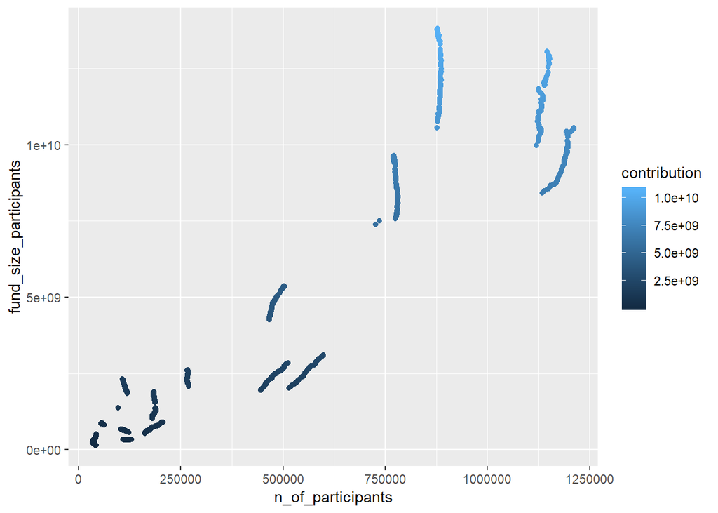

```r
ggplot(data = data, aes(x = n_of_participants, y = fund_size_participants, color = contribution)) + geom_point()
```

#Listing companies which have better proposals Lets see which company is best for fund and other proposals. We see “Allianz Hayat ve Emeklilik” is the best company for retirement probabilities.

```r
data %>%
 mutate(propTotal = size_total / n_total, propFund = fund_size_participants / n_of_participants) %>%
 select(pension_fund_company,propTotal,propFund)%>%
  filter(propTotal + propFund > 30000) %>%

  arrange(desc(propFund))
```

```
## # A tibble: 45 x 3
##    pension_fund_company       propTotal propFund
##    <chr>                          <dbl>    <dbl>
##  1 Allianz Hayat ve Emeklilik    13551.   21602.
##  2 Allianz Hayat ve Emeklilik    13503.   21545.
##  3 Allianz Hayat ve Emeklilik    13453.   21420.
##  4 Allianz Hayat ve Emeklilik    13355.   21283.
##  5 Allianz Hayat ve Emeklilik    13405.   21276.
##  6 Allianz Hayat ve Emeklilik    13365.   21248.
##  7 Allianz Hayat ve Emeklilik    13316.   21188.
##  8 Allianz Hayat ve Emeklilik    13163.   21081.
##  9 Allianz Hayat ve Emeklilik    13195.   21078.
## 10 Allianz Hayat ve Emeklilik    13188.   21074.
## # ... with 35 more rows
```

# Contracts and Goverment Contribution

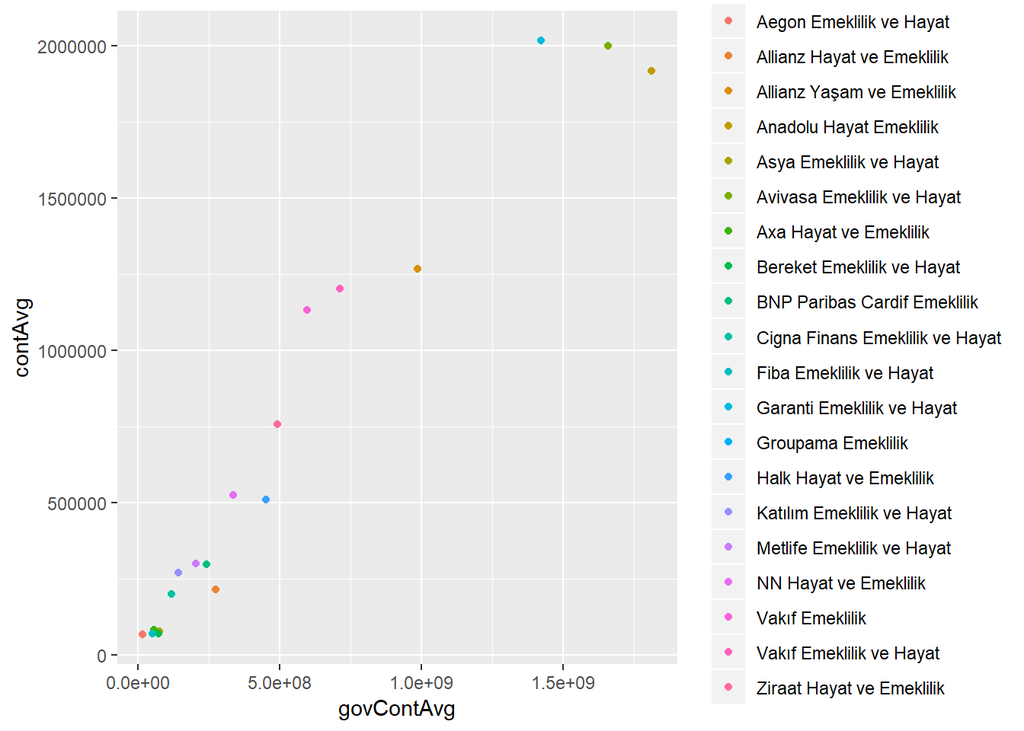

```r
data %>%
  group_by(pension_fund_company) %>%
  mutate(contracts = n_of_ind_contracts + n_of_ind_contracts) %>%
  select(gov_contribution,contracts) %>%
  summarise(govContAvg = mean(gov_contribution),contAvg = mean(contracts)) %>%
  arrange(desc(govContAvg)) %>%
  ggplot(aes(x = govContAvg, y = contAvg, color = pension_fund_company)) + geom_point()
```

And to be clear, you can see the list of companies

```r
data %>%
  group_by(pension_fund_company) %>%
  mutate(contracts = n_of_ind_contracts + n_of_ind_contracts) %>%
  select(gov_contribution,contracts) %>%
  summarise(govContAvg = mean(gov_contribution),contAvg = mean(contracts)) %>%
  arrange(desc(govContAvg))
```

```
## # A tibble: 20 x 3
##    pension_fund_company             govContAvg  contAvg
##    <chr>                                 <dbl>    <dbl>
##  1 Anadolu Hayat Emeklilik         1812891868. 1917969.
##  2 Avivasa Emeklilik ve Hayat      1659169052. 2000998.
##  3 Garanti Emeklilik ve Hayat      1421056644. 2018201.
##  4 Allianz Yaşam ve Emeklilik       986490138. 1268631.
##  5 Vakıf Emeklilik ve Hayat         712214429. 1201556.
##  6 Vakıf Emeklilik                  597511296. 1131911.
##  7 Ziraat Hayat ve Emeklilik        492573034.  756586.
##  8 Halk Hayat ve Emeklilik          449886158.  509265.
##  9 NN Hayat ve Emeklilik            335923127.  525506.
## 10 Allianz Hayat ve Emeklilik       272992884.  214963.
## 11 BNP Paribas Cardif Emeklilik     241038796.  295783.
## 12 Metlife Emeklilik ve Hayat       204758206.  300211.
## 13 Katılım Emeklilik ve Hayat       141938310.  270083.
## 14 Cigna Finans Emeklilik ve Hayat  116977057.  198454.
## 15 Asya Emeklilik ve Hayat           75743346.   76840.
## 16 Bereket Emeklilik ve Hayat        70691530.   68554.
## 17 Axa Hayat ve Emeklilik            54726264.   81346.
## 18 Fiba Emeklilik ve Hayat           50442742.   68160.
## 19 Aegon Emeklilik ve Hayat          15441978.   65663.
## 20 Groupama Emeklilik                      NA       NA
```

## Personal gatherings of Companies

So, I summed the number of personas and their applications on retirement companies and summarise it in table. After that, I measure the distinct values on table to see which companies are good and which are worse by the measure of individual impact.

```r
data %>%group_by(pension_fund_company)%>%
  mutate(indSum = (as.numeric(n_of_participants) + as.numeric(n_of_pensioners) + as.numeric(n_of_ind_contracts) + as.numeric(n_of_employer_group_certificates))) %>%
  select(indSum) %>%
  arrange(desc(indSum)) %>%
  distinct(pension_fund_company)
```

```
## # A tibble: 20 x 1
## # Groups:   pension_fund_company [20]
##    pension_fund_company
##    <chr>
##  1 Garanti Emeklilik ve Hayat
##  2 Anadolu Hayat Emeklilik
##  3 Avivasa Emeklilik ve Hayat
##  4 Allianz Yaşam ve Emeklilik
##  5 Vakıf Emeklilik ve Hayat
##  6 Vakıf Emeklilik
##  7 Ziraat Hayat ve Emeklilik
##  8 Halk Hayat ve Emeklilik
##  9 NN Hayat ve Emeklilik
## 10 Katılım Emeklilik ve Hayat
## 11 BNP Paribas Cardif Emeklilik
## 12 Metlife Emeklilik ve Hayat
## 13 Allianz Hayat ve Emeklilik
## 14 Cigna Finans Emeklilik ve Hayat
## 15 Asya Emeklilik ve Hayat
## 16 Bereket Emeklilik ve Hayat
## 17 Fiba Emeklilik ve Hayat
## 18 Groupama Emeklilik
## 19 Axa Hayat ve Emeklilik
## 20 Aegon Emeklilik ve Hayat
```

If you want to see the graph of this table:

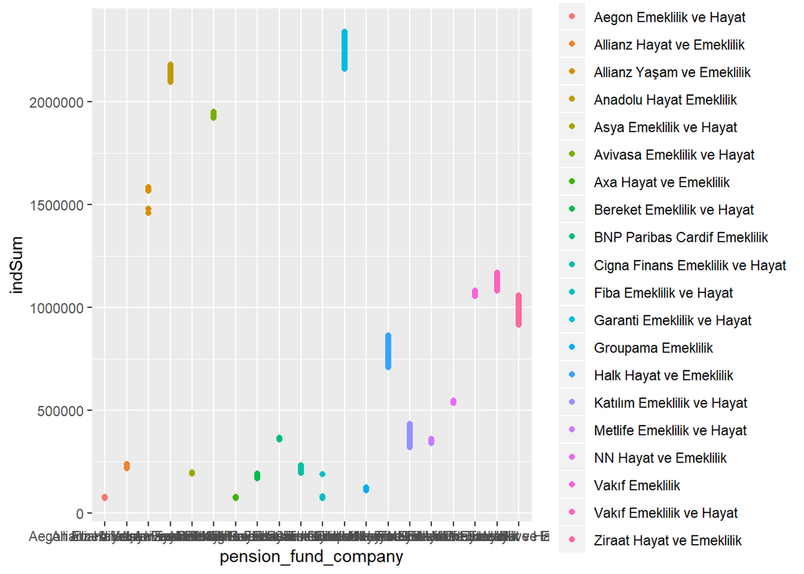

```r
data %>%group_by(pension_fund_company)%>%
  mutate(indSum = (as.numeric(n_of_participants) + as.numeric(n_of_pensioners) + as.numeric(n_of_ind_contracts) + as.numeric(n_of_employer_group_certificates))) %>%
  select(indSum) %>%
  arrange(desc(indSum)) %>% ggplot(aes(x = pension_fund_company,y = indSum, color = pension_fund_company)) + geom_point()
```

## Total Change of Companies

At last, you can want to see changes in total or other variables. I can simlpy make a graph of size_total to show total changes.

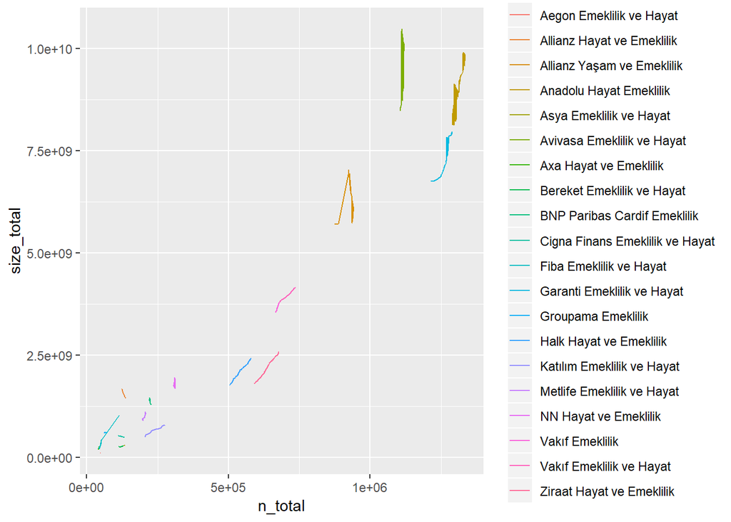

```r
data %>% group_by(pension_fund_company) %>%
  select(size_total,n_total) %>%
  arrange(size_total) %>%
  ggplot(aes(x = n_total, y = size_total,color=pension_fund_company)) + geom_line()
```

If you don’t understand easily, I can show you the table of this chart to see the top values on it.You can see the top values by the means of avg size_total value.

```r
data %>% group_by(pension_fund_company) %>%
  select(size_total,n_total) %>%
  summarise(sizeAvg = mean(size_total),nAvg = mean(n_total)) %>%
  arrange(desc(sizeAvg)) %>%
  distinct
```

```
## # A tibble: 20 x 3
##    pension_fund_company                sizeAvg     nAvg
##    <chr>                                 <dbl>    <dbl>
##  1 Avivasa Emeklilik ve Hayat      9427183177. 1114567.
##  2 Anadolu Hayat Emeklilik         8951986575. 1309971.
##  3 Garanti Emeklilik ve Hayat      7342203249. 1264901.
##  4 Allianz Yaşam ve Emeklilik      6337016594.  932642.
##  5 Vakıf Emeklilik ve Hayat        3964040974.  706774.
##  6 Vakıf Emeklilik                 3672775808.  673302.
##  7 Ziraat Hayat ve Emeklilik       2186487302.  635485.
##  8 Halk Hayat ve Emeklilik         2095445535.  541190.
##  9 NN Hayat ve Emeklilik           1800532651.  309378.
## 10 Allianz Hayat ve Emeklilik      1559554275.  129664.
## 11 BNP Paribas Cardif Emeklilik    1370387322.  223224.
## 12 Metlife Emeklilik ve Hayat      1011349369.  203391.
## 13 Katılım Emeklilik ve Hayat       638027668.  233372.
## 14 Cigna Finans Emeklilik ve Hayat  510333188.  121007.
## 15 Fiba Emeklilik ve Hayat          334790910.   48915.
## 16 Asya Emeklilik ve Hayat          288930339.  132885
## 17 Bereket Emeklilik ve Hayat       259709813.  119469.
## 18 Axa Hayat ve Emeklilik           227035040.   42409.
## 19 Aegon Emeklilik ve Hayat         102665246.   47594.
## 20 Groupama Emeklilik                      NA       NA
```